# Введение в машинное обучение

## Предварительный анализ данных

```python
import pandas as pd
import numpy as np
```

```python
import matplotlib.pyplot as plt
%matplotlib inline
```

```python
df = pd.read_csv('./data/cs-training.csv', sep=',')
```

```python
df.head()
```

|  | SeriousDlqin2yrs | RevolvingUtilizationOfUnsecuredLines | age | NumberOfTime30-59DaysPastDueNotWorse | DebtRatio | MonthlyIncome | NumberOfOpenCreditLinesAndLoans | NumberOfTimes90DaysLate | NumberRealEstateLoansOrLines | NumberOfTime60-89DaysPastDueNotWorse | NumberOfDependents |
| --- | --- | --- | --- | --- | --- | --- | --- | --- | --- | --- | --- |
| 1 | 1 | 0.766127 | 45 | 2 | 0.802982 | 9120.0 | 13 | 0 | 6 | 0 | 2.0 |
| 2 | 0 | 0.957151 | 40 | 0 | 0.121876 | 2600.0 | 4 | 0 | 0 | 0 | 1.0 |
| 3 | 0 | 0.658180 | 38 | 1 | 0.085113 | 3042.0 | 2 | 1 | 0 | 0 | 0.0 |
| 4 | 0 | 0.233810 | 30 | 0 | 0.036050 | 3300.0 | 5 | 0 | 0 | 0 | 0.0 |
| 5 | 0 | 0.907239 | 49 | 1 | 0.024926 | 63588.0 | 7 | 0 | 1 | 0 | 0.0 |

## Описание данных

- SeriousDlqin2yrs - Person experienced 90 days past due delinquency or worse
- RevolvingUtilizationOfUnsecuredLines - Total balance on credit cards and personal lines of credit except real estate and no installment debt like car loans divided by the sum of credit limits
- age - Age of borrower in years
- NumberOfTime30-59DaysPastDueNotWorse - Number of times borrower has been 30-59 days past due but no worse in the last 2 years.
- DebtRatio - Monthly debt payments, alimony,living costs divided by monthy gross income
- MonthlyIncome - Monthly income
- NumberOfOpenCreditLinesAndLoans - Number of Open loans (installment like car loan or mortgage) and Lines of credit (e.g. credit cards)
- NumberOfTimes90DaysLate - Number of times borrower has been 90 days or more past due.
- NumberRealEstateLoansOrLines - Number of mortgage and real estate loans including home equity lines of credit
- NumberOfTime60-89DaysPastDueNotWorse - Number of times borrower has been 60-89 days past due but no worse in the last 2 years.
- NumberOfDependents - Number of dependents in family excluding themselves (spouse, children etc.)
- SeriousDlqin2yrs - Флаг выхода на просрочку через 90 дней
- RevolvingUtilizationOfUnsecuredLines - Общий баланс по кредитным картам и личным кредитным линиям, за исключением недвижимости, и без задолженности по кредитам, таким как автокредиты, деленные на сумму кредитных лимитов
- age - Возраст заёмщика в годах
- NumberOfTime30-59DaysPastDueNotWorse - Сколько раз заемщик просрочил выплату не более, чем на 30-59 дней, за последние 2 года.
- DebtRatio - Ежемесячные платежи по долгам, алименты и прожиточные расходы, делённые на месячный валовый доход
- MonthlyIncome - Ежемесячный доход
- NumberOfOpenCreditLinesAndLoans - Количество открытых кредитов (например, автокредит или закладная, кредитные карты и т.д.)
- NumberOfTimes90DaysLate - Сколько раз заёмщик просрочил выплату на 90 дней и более.
- NumberRealEstateLoansOrLines - Количество ипотечных кредитов и кредитов на недвижимость
- NumberOfTime60-89DaysPastDueNotWorse - Сколько раз заёмщик просрочил выплату не более, чем на 60-89 дней, за последние 2 года.
- NumberOfDependents - Количество иждивенцев в семье, исключая самого заёмщика (супруга, дети и т.д.)

## 1) Смотрим размер набора данных

см. shape

```python
df.shape
```

```
(150000, 11)
```

## 2) Выводим названия колонок

см. columns

```python
df.columns
```

```
Index(['SeriousDlqin2yrs', 'RevolvingUtilizationOfUnsecuredLines', 'age',
       'NumberOfTime30-59DaysPastDueNotWorse', 'DebtRatio', 'MonthlyIncome',
       'NumberOfOpenCreditLinesAndLoans', 'NumberOfTimes90DaysLate',
       'NumberRealEstateLoansOrLines', 'NumberOfTime60-89DaysPastDueNotWorse',
       'NumberOfDependents'],
      dtype='object')
```

## 3) Смотрим информацию по каждой колонке

см. info

```python
df.info()
```

```
<class 'pandas.core.frame.DataFrame'>
Index: 150000 entries, 1 to 150000
Data columns (total 11 columns):
 #   Column                                Non-Null Count   Dtype
---  ------                                --------------   -----
 0   SeriousDlqin2yrs                      150000 non-null  int64
 1   RevolvingUtilizationOfUnsecuredLines  150000 non-null  float64
 2   age                                   150000 non-null  int64
 3   NumberOfTime30-59DaysPastDueNotWorse  150000 non-null  int64
 4   DebtRatio                             150000 non-null  float64
 5   MonthlyIncome                         120269 non-null  float64
 6   NumberOfOpenCreditLinesAndLoans       150000 non-null  int64
 7   NumberOfTimes90DaysLate               150000 non-null  int64
 8   NumberRealEstateLoansOrLines          150000 non-null  int64
 9   NumberOfTime60-89DaysPastDueNotWorse  150000 non-null  int64
 10  NumberOfDependents                    146076 non-null  float64
dtypes: float64(4), int64(7)
memory usage: 13.7 MB
```

## 4) Выводим характеристики каждого признака

см. describe

```python
df.describe()
```

|  | SeriousDlqin2yrs | RevolvingUtilizationOfUnsecuredLines | age | NumberOfTime30-59DaysPastDueNotWorse | DebtRatio | MonthlyIncome | NumberOfOpenCreditLinesAndLoans | NumberOfTimes90DaysLate | NumberRealEstateLoansOrLines | NumberOfTime60-89DaysPastDueNotWorse | NumberOfDependents |
| --- | --- | --- | --- | --- | --- | --- | --- | --- | --- | --- | --- |
| count | 150000.000000 | 150000.000000 | 150000.000000 | 150000.000000 | 150000.000000 | 1.202690e+05 | 150000.000000 | 150000.000000 | 150000.000000 | 150000.000000 | 146076.000000 |
| mean | 0.066840 | 6.048438 | 52.295207 | 0.421033 | 353.005076 | 6.670221e+03 | 8.452760 | 0.265973 | 1.018240 | 0.240387 | 0.757222 |
| std | 0.249746 | 249.755371 | 14.771866 | 4.192781 | 2037.818523 | 1.438467e+04 | 5.145951 | 4.169304 | 1.129771 | 4.155179 | 1.115086 |
| min | 0.000000 | 0.000000 | 0.000000 | 0.000000 | 0.000000 | 0.000000e+00 | 0.000000 | 0.000000 | 0.000000 | 0.000000 | 0.000000 |
| 25% | 0.000000 | 0.029867 | 41.000000 | 0.000000 | 0.175074 | 3.400000e+03 | 5.000000 | 0.000000 | 0.000000 | 0.000000 | 0.000000 |
| 50% | 0.000000 | 0.154181 | 52.000000 | 0.000000 | 0.366508 | 5.400000e+03 | 8.000000 | 0.000000 | 1.000000 | 0.000000 | 0.000000 |
| 75% | 0.000000 | 0.559046 | 63.000000 | 0.000000 | 0.868254 | 8.249000e+03 | 11.000000 | 0.000000 | 2.000000 | 0.000000 | 1.000000 |
| max | 1.000000 | 50708.000000 | 109.000000 | 98.000000 | 329664.000000 | 3.008750e+06 | 58.000000 | 98.000000 | 54.000000 | 98.000000 | 20.000000 |

## 5) Выводим соотношение между 1 и 0 для SeriousDlqin2yrs

см. value_counts

```python
pd.value_counts(df["SeriousDlqin2yrs"])
```

```
SeriousDlqin2yrs
0    139974
1     10026
Name: count, dtype: int64
```

## 6) Определим средний возраст

см. mean

```python
df["age"].mean()
```

```
np.float64(52.295206666666665)
```

## 7) Создадим свобную табличку для SeriousDlqin2yrs по признакам:

- NumberOfTime30-59DaysPastDueNotWorse
- NumberOfTime60-89DaysPastDueNotWorse
- NumberOfTimes90DaysLate

Соберём по mean

см. pivot_table

```python
pd.pivot_table??
```

[output not shown]

[output cut: 165 more lines]

[output not shown]

```python
pd.pivot_table(
    df,
    columns=[
        "NumberOfTime30-59DaysPastDueNotWorse",
        "NumberOfTime60-89DaysPastDueNotWorse",
        "NumberOfTimes90DaysLate"
    ],
    aggfunc='mean'
)
```

| NumberOfTime30-59DaysPastDueNotWorse NumberOfTime60-89DaysPastDueNotWorse NumberOfTimes90DaysLate | 0 | 0 1 | 0 2 | 0 3 | 0 4 | 0 5 | 0 6 | 0 7 | 0 8 | 0 9 | ... | 9 3 0 | 10 0 | 10 1 3 | 10 2 3 | 10 5 2 | 11 1 | 12 1 0 | 13 0 | 96 | 98 |
| --- | --- | --- | --- | --- | --- | --- | --- | --- | --- | --- | --- | --- | --- | --- | --- | --- | --- | --- | --- | --- | --- |
| DebtRatio | 358.308857 | 214.861514 | 145.127334 | 93.461178 | 303.256769 | 337.864136 | 318.166070 | 128.590649 | 167.396891 | 162.979109 | ... | 0.673775 | 0.298234 | 0.33162 | 4793.000000 | 1.297901 | 0.534183 | 0.387167 | 0.348064 | 0.011962 | 5.848146 |
| MonthlyIncome | 6757.230249 | 5257.057496 | 4545.005236 | 4605.090909 | 3926.620000 | 4957.347826 | 4110.769231 | 3132.250000 | 3837.000000 | 3886.200000 | ... | 3000.000000 | 3000.000000 | 3500.00000 | NaN | 3000.000000 | 3685.000000 | 6397.000000 | 12083.000000 | 3754.000000 | 2523.888889 |
| NumberOfDependents | 0.717534 | 0.789658 | 0.824742 | 0.807692 | 0.814286 | 0.696970 | 1.166667 | 1.100000 | 0.555556 | 1.285714 | ... | 0.000000 | 0.000000 | 0.00000 | 0.000000 | 1.000000 | 0.000000 | 0.000000 | 3.000000 | 0.600000 | 0.364807 |
| NumberOfOpenCreditLinesAndLoans | 8.426189 | 5.926672 | 3.678715 | 3.630435 | 3.690141 | 3.666667 | 4.722222 | 4.000000 | 4.666667 | 7.714286 | ... | 25.000000 | 12.000000 | 7.00000 | 26.000000 | 11.000000 | 17.000000 | 13.500000 | 15.000000 | 0.000000 | 0.007576 |
| NumberRealEstateLoansOrLines | 1.022025 | 0.587907 | 0.349398 | 0.364130 | 0.211268 | 0.272727 | 0.444444 | 0.200000 | 0.222222 | 0.285714 | ... | 0.000000 | 0.000000 | 0.00000 | 2.000000 | 3.000000 | 0.000000 | 0.500000 | 1.000000 | 0.000000 | 0.000000 |
| RevolvingUtilizationOfUnsecuredLines | 6.261991 | 10.416418 | 0.818823 | 0.854505 | 0.973282 | 0.959648 | 0.936279 | 0.869317 | 1.063875 | 0.920187 | ... | 0.791090 | 0.591541 | 1.05431 | 0.587127 | 0.991502 | 0.993470 | 0.648200 | 0.998833 | 1.000000 | 1.000000 |
| SeriousDlqin2yrs | 0.027283 | 0.235849 | 0.385542 | 0.500000 | 0.478873 | 0.424242 | 0.555556 | 0.800000 | 0.777778 | 0.571429 | ... | 0.000000 | 0.000000 | 1.00000 | 1.000000 | 1.000000 | 1.000000 | 0.500000 | 1.000000 | 0.800000 | 0.541667 |
| age | 53.240034 | 47.102058 | 43.722892 | 44.076087 | 42.253521 | 41.515152 | 40.555556 | 39.900000 | 37.444444 | 43.285714 | ... | 80.000000 | 54.000000 | 53.00000 | 59.000000 | 61.000000 | 51.000000 | 45.000000 | 48.000000 | 33.600000 | 34.257576 |

8 rows × 335 columns

см. hist

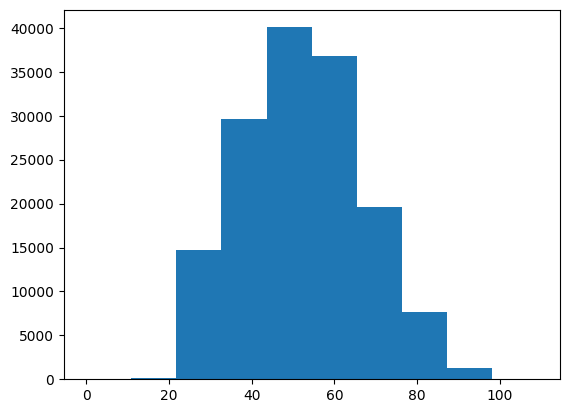

```python
column_data = df["age"]

plt.figure()

plt.hist(column_data)
```

## 9) Посмотрим на частоты признака NumberOfDependents

см. value_counts + normalize

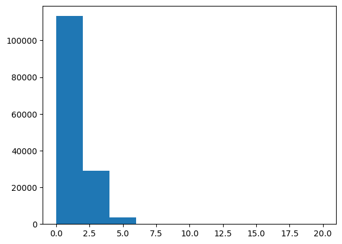

```python
column_data = df["NumberOfDependents"]

plt.figure()

plt.hist(column_data)
```

## 10) Узнаем максимальное значение по каждому признаку

см. apply + max

```python
df.max()
```

```
SeriousDlqin2yrs                              1.0
RevolvingUtilizationOfUnsecuredLines      50708.0
age                                         109.0
NumberOfTime30-59DaysPastDueNotWorse         98.0
DebtRatio                                329664.0
MonthlyIncome                           3008750.0
NumberOfOpenCreditLinesAndLoans              58.0
NumberOfTimes90DaysLate                      98.0
NumberRealEstateLoansOrLines                 54.0
NumberOfTime60-89DaysPastDueNotWorse         98.0
NumberOfDependents                           20.0
dtype: float64
```

## 11) Выведем ту часть таблицы, для которой значение признака age > 65

см. map + lambda

```python
df[df["age"] > 65]
```

|  | SeriousDlqin2yrs | RevolvingUtilizationOfUnsecuredLines | age | NumberOfTime30-59DaysPastDueNotWorse | DebtRatio | MonthlyIncome | NumberOfOpenCreditLinesAndLoans | NumberOfTimes90DaysLate | NumberRealEstateLoansOrLines | NumberOfTime60-89DaysPastDueNotWorse | NumberOfDependents |
| --- | --- | --- | --- | --- | --- | --- | --- | --- | --- | --- | --- |
| 6 | 0 | 0.213179 | 74 | 0 | 0.375607 | 3500.0 | 3 | 0 | 1 | 0 | 1.0 |
| 15 | 0 | 0.019657 | 76 | 0 | 477.000000 | 0.0 | 6 | 0 | 1 | 0 | 0.0 |
| 17 | 0 | 0.061086 | 78 | 0 | 2058.000000 | NaN | 10 | 0 | 2 | 0 | 0.0 |
| 28 | 0 | 0.034421 | 69 | 0 | 0.042383 | 2500.0 | 17 | 0 | 0 | 0 | 1.0 |
| 38 | 0 | 1.000000 | 75 | 1 | 0.134078 | 3400.0 | 1 | 0 | 1 | 0 | 1.0 |
| ... | ... | ... | ... | ... | ... | ... | ... | ... | ... | ... | ... |
| 149972 | 0 | 0.058001 | 83 | 0 | 0.013997 | 5000.0 | 6 | 0 | 0 | 0 | 0.0 |
| 149977 | 0 | 0.000627 | 76 | 0 | 60.000000 | NaN | 5 | 0 | 0 | 0 | 0.0 |
| 149984 | 0 | 0.002485 | 82 | 0 | 0.000800 | 5000.0 | 5 | 0 | 0 | 0 | 0.0 |
| 149985 | 0 | 0.037548 | 84 | 0 | 25.000000 | NaN | 5 | 0 | 0 | 0 | 0.0 |
| 149996 | 0 | 0.040674 | 74 | 0 | 0.225131 | 2100.0 | 4 | 0 | 1 | 0 | 0.0 |

28599 rows × 11 columns

## 12) Сгруппируем таблицу по SeriousDlqin2yrs и посмотрим статистику для признаков 'RevolvingUtilizationOfUnsecuredLines', 'age', 'DebtRatio'

см. groupby + describe(percentiles=[])

```python
df.groupby(by=["SeriousDlqin2yrs"])[[
    'RevolvingUtilizationOfUnsecuredLines',
    'age',
    'DebtRatio'
]].describe(percentiles=[])
```

| SeriousDlqin2yrs | RevolvingUtilizationOfUnsecuredLines count | RevolvingUtilizationOfUnsecuredLines mean | RevolvingUtilizationOfUnsecuredLines std | RevolvingUtilizationOfUnsecuredLines min | RevolvingUtilizationOfUnsecuredLines 50% | RevolvingUtilizationOfUnsecuredLines max | age count | age mean | age std | age min | age 50% | age max | DebtRatio count | DebtRatio mean | DebtRatio std | DebtRatio min | DebtRatio 50% | DebtRatio max |
| --- | --- | --- | --- | --- | --- | --- | --- | --- | --- | --- | --- | --- | --- | --- | --- | --- | --- | --- |
| 0 | 139974.0 | 6.168855 | 256.126350 | 0.0 | 0.133288 | 50708.0 | 139974.0 | 52.751375 | 14.791079 | 0.0 | 52.0 | 109.0 | 139974.0 | 357.151168 | 2083.282060 | 0.0 | 0.362659 | 329664.0 |
| 1 | 10026.0 | 4.367282 | 131.835778 | 0.0 | 0.838853 | 8328.0 | 10026.0 | 45.926591 | 12.916289 | 21.0 | 45.0 | 101.0 | 10026.0 | 295.121066 | 1238.360283 | 0.0 | 0.428227 | 38793.0 |

## 13) Тоже самое, только для mean, std, min, max

см. groupby + agg + [np.mean, np.std, np.min, np.max]

```python
df.groupby(by=["SeriousDlqin2yrs"])[[
    'RevolvingUtilizationOfUnsecuredLines',
    'age',
    'DebtRatio'
]].agg("mean")
```

| SeriousDlqin2yrs | RevolvingUtilizationOfUnsecuredLines | age | DebtRatio |
| --- | --- | --- | --- |
| 0 | 6.168855 | 52.751375 | 357.151168 |
| 1 | 4.367282 | 45.926591 | 295.121066 |

```python
df.groupby(by=["SeriousDlqin2yrs"])[[
    'RevolvingUtilizationOfUnsecuredLines',
    'age',
    'DebtRatio'
]].agg("std")
```

| SeriousDlqin2yrs | RevolvingUtilizationOfUnsecuredLines | age | DebtRatio |
| --- | --- | --- | --- |
| 0 | 256.126350 | 14.791079 | 2083.282060 |
| 1 | 131.835778 | 12.916289 | 1238.360283 |

```python
df.groupby(by=["SeriousDlqin2yrs"])[[
    'RevolvingUtilizationOfUnsecuredLines',
    'age',
    'DebtRatio'
]].agg("min")
```

| SeriousDlqin2yrs | RevolvingUtilizationOfUnsecuredLines | age | DebtRatio |
| --- | --- | --- | --- |
| 0 | 0.0 | 0 | 0.0 |
| 1 | 0.0 | 21 | 0.0 |

```python
df.groupby(by=["SeriousDlqin2yrs"])[[
    'RevolvingUtilizationOfUnsecuredLines',
    'age',
    'DebtRatio'
]].agg("max")
```

| SeriousDlqin2yrs | RevolvingUtilizationOfUnsecuredLines | age | DebtRatio |
| --- | --- | --- | --- |
| 0 | 50708.0 | 109 | 329664.0 |
| 1 | 8328.0 | 101 | 38793.0 |

см. crosstab

```python
pd.crosstab(df["SeriousDlqin2yrs"], df["SeriousDlqin2yrs"])
```

| SeriousDlqin2yrs | 0 | 1 |
| --- | --- | --- |
| 0 | 139974 | 0 |
| 1 | 0 | 10026 |

см. crosstab + normalize=True

```python
pd.crosstab(df["SeriousDlqin2yrs"], df["SeriousDlqin2yrs"], normalize=True)
```

| SeriousDlqin2yrs | 0 | 1 |
| --- | --- | --- |
| 0 | 0.93316 | 0.00000 |
| 1 | 0.00000 | 0.06684 |